# ppatil8_hw3_ex

Prachi Vijay Patil

2023-10-19

#6.6

#Q.8

#8a

```r
library(leaps)
library(ISLR2)
library(glmnet)
set.seed(100)
X <- rnorm(100)
e <- rnorm(100)
```

#8b

#values of b0, b1, b2, b3 are assumed as: #b0 = 20 #b1 = -10 #b2 = 5 #b3 = -1.5

```r
Y <- 20 - 10 * X +5 * X^2 + (-1.5) * X^3 + e
```

#8c

```r
library(leaps)
data.full <- data.frame(y = Y, x = X)
regfit.full <- regsubsets(y~x+I(x^2) + I(x^3) + I(x^4) + I(x^5) + I(x^6) + I(x^7) + I(x^8) + I(x^9) + I(x^10), data = data.full, nvmax = 10,really.big = T)
reg.summary <- summary(regfit.full)
reg.summary
```

```
## Subset selection object
## Call: regsubsets.formula(y ~ x + I(x^2) + I(x^3) + I(x^4) + I(x^5) +
##     I(x^6) + I(x^7) + I(x^8) + I(x^9) + I(x^10), data = data.full,
##     nvmax = 10, really.big = T)
## 10 Variables  (and intercept)
##         Forced in Forced out
## x           FALSE      FALSE
## I(x^2)      FALSE      FALSE
## I(x^3)      FALSE      FALSE
## I(x^4)      FALSE      FALSE
## I(x^5)      FALSE      FALSE
## I(x^6)      FALSE      FALSE
## I(x^7)      FALSE      FALSE
## I(x^8)      FALSE      FALSE
## I(x^9)      FALSE      FALSE
## I(x^10)     FALSE      FALSE
## 1 subsets of each size up to 10
## Selection Algorithm: exhaustive
##           x   I(x^2) I(x^3) I(x^4) I(x^5) I(x^6) I(x^7) I(x^8) I(x^9) I(x^10)
## 1  ( 1 )  "*" " "    " "    " "    " "    " "    " "    " "    " "    " "
## 2  ( 1 )  "*" "*"    " "    " "    " "    " "    " "    " "    " "    " "
## 3  ( 1 )  "*" "*"    "*"    " "    " "    " "    " "    " "    " "    " "
## 4  ( 1 )  "*" "*"    "*"    "*"    " "    " "    " "    " "    " "    " "
## 5  ( 1 )  "*" "*"    "*"    "*"    "*"    " "    " "    " "    " "    " "
## 6  ( 1 )  "*" "*"    "*"    " "    "*"    " "    " "    "*"    " "    "*"
## 7  ( 1 )  "*" "*"    "*"    "*"    " "    "*"    " "    "*"    " "    "*"
## 8  ( 1 )  "*" "*"    "*"    "*"    "*"    "*"    " "    "*"    " "    "*"
## 9  ( 1 )  "*" "*"    "*"    "*"    " "    "*"    "*"    "*"    "*"    "*"
## 10  ( 1 ) "*" "*"    "*"    "*"    "*"    "*"    "*"    "*"    "*"    "*"
```

```r
reg.summary$cp
```

```
##  [1] 8119.283890 1201.181577    3.821967    3.846742    5.309942    6.014323
##  [7]    6.523634    7.149537    9.041056   11.000000
```

```r
reg.summary$bic
```

```
##  [1] -148.0650 -328.1944 -583.9807 -581.4584 -577.4268 -574.2199 -571.2481
##  [8] -568.1725 -563.6891 -559.1300
```

```r
reg.summary$adjr2
```

```
##  [1] 0.7904099 0.9666164 0.9975044 0.9975302 0.9975182 0.9975263 0.9975399
##  [8] 0.9975506 0.9975264 0.9974998
```

#cp decreases substancially from one variable model to two variable model. Again from two variable model to three variable model it decreases substancially and then it keeps incresing

#BIC value is almost constant after three variable model and it is lowest for three variable model

```r
par(mfrow = c(1, 3))

plot(reg.summary$cp,xlab="Number of Variables",ylab="cp",type="l")
points(which.min(reg.summary$cp),reg.summary$cp[which.min(reg.summary$cp)],col="blue",cex=2,pch=20)
which.min(reg.summary$cp)
```

```
## [1] 3
```

```r
plot(reg.summary$bic,xlab="Number of Variables",ylab="BIC",type="l")
points(which.min(reg.summary$bic),reg.summary$bic[which.min(reg.summary$bic)],col="red",cex=2,pch=20)
which.min(reg.summary$bic)
```

```
## [1] 3
```

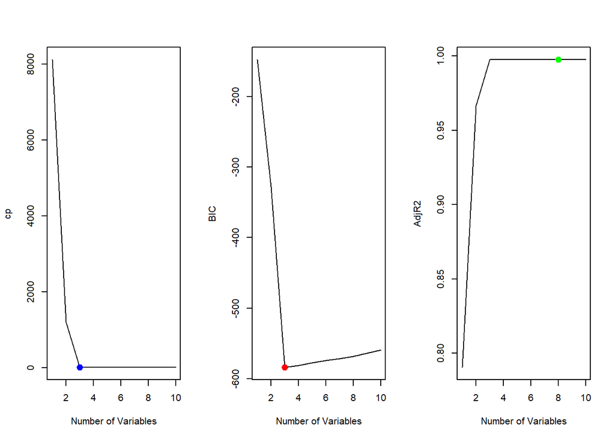

```r
plot(reg.summary$adjr2,xlab="Number of Variables",ylab="AdjR2",type="l")
points(which.max(reg.summary$adjr2),reg.summary$adjr2[which.max(reg.summary$adjr2)],col="green",cex=2,pch=20)
```

```r
which.max(reg.summary$adjr2)
```

```
## [1] 8
```

#8d

# Stepwise Forward

```r
data.full <- data.frame(y = Y, x = X)
regfit.f <- regsubsets(y~x+I(x^2) + I(x^3) + I(x^4) + I(x^5) + I(x^6) + I(x^7) + I(x^8) + I(x^9) + I(x^10), data = data.full, nvmax = 10,really.big = T, method = 'forward')
regf.summary <- summary(regfit.f)
regf.summary
```

```
## Subset selection object
## Call: regsubsets.formula(y ~ x + I(x^2) + I(x^3) + I(x^4) + I(x^5) +
##     I(x^6) + I(x^7) + I(x^8) + I(x^9) + I(x^10), data = data.full,
##     nvmax = 10, really.big = T, method = "forward")
## 10 Variables  (and intercept)
##         Forced in Forced out
## x           FALSE      FALSE
## I(x^2)      FALSE      FALSE
## I(x^3)      FALSE      FALSE
## I(x^4)      FALSE      FALSE
## I(x^5)      FALSE      FALSE
## I(x^6)      FALSE      FALSE
## I(x^7)      FALSE      FALSE
## I(x^8)      FALSE      FALSE
## I(x^9)      FALSE      FALSE
## I(x^10)     FALSE      FALSE
## 1 subsets of each size up to 10
## Selection Algorithm: forward
##           x   I(x^2) I(x^3) I(x^4) I(x^5) I(x^6) I(x^7) I(x^8) I(x^9) I(x^10)
## 1  ( 1 )  "*" " "    " "    " "    " "    " "    " "    " "    " "    " "
## 2  ( 1 )  "*" "*"    " "    " "    " "    " "    " "    " "    " "    " "
## 3  ( 1 )  "*" "*"    "*"    " "    " "    " "    " "    " "    " "    " "
## 4  ( 1 )  "*" "*"    "*"    "*"    " "    " "    " "    " "    " "    " "
## 5  ( 1 )  "*" "*"    "*"    "*"    "*"    " "    " "    " "    " "    " "
## 6  ( 1 )  "*" "*"    "*"    "*"    "*"    " "    " "    " "    "*"    " "
## 7  ( 1 )  "*" "*"    "*"    "*"    "*"    " "    "*"    " "    "*"    " "
## 8  ( 1 )  "*" "*"    "*"    "*"    "*"    "*"    "*"    " "    "*"    " "
## 9  ( 1 )  "*" "*"    "*"    "*"    "*"    "*"    "*"    "*"    "*"    " "
## 10  ( 1 ) "*" "*"    "*"    "*"    "*"    "*"    "*"    "*"    "*"    "*"
```

```r
regf.summary$cp
```

```
##  [1] 8119.283890 1201.181577    3.821967    3.846742    5.309942    6.559954
##  [7]    8.405294   10.341587   10.191842   11.000000
```

```r
regf.summary$bic
```

```
##  [1] -148.0650 -328.1944 -583.9807 -581.4584 -577.4268 -573.6287 -569.1907
##  [8] -564.6545 -562.4049 -559.1300
```

```r
regf.summary$adjr2
```

```
##  [1] 0.7904099 0.9666164 0.9975044 0.9975302 0.9975182 0.9975116 0.9974888
##  [8] 0.9974629 0.9974945 0.9974998
```

#The statistical matrices are very similar to that for best subset selection

#cp decreases substancially from one variable model to two variable model. Again from two variable model to three variable model it decreases substancially and then again it keeps incresing

#BIC value is almost constant after three variable model and it is lowest for three variable model

```r
par(mfrow = c(1, 3))

plot(reg.summary$cp,xlab="Number of Variables",ylab="cp",type="l")
points(which.min(regf.summary$cp),regf.summary$cp[which.min(regf.summary$cp)],col="blue",cex=2,pch=20)
which.min(regf.summary$cp)
```

```
## [1] 3
```

```r
plot(reg.summary$bic,xlab="Number of Variables",ylab="BIC",type="l")
points(which.min(reg.summary$bic),regf.summary$bic[which.min(regf.summary$bic)],col="red",cex=2,pch=20)
which.min(regf.summary$bic)
```

```
## [1] 3
```

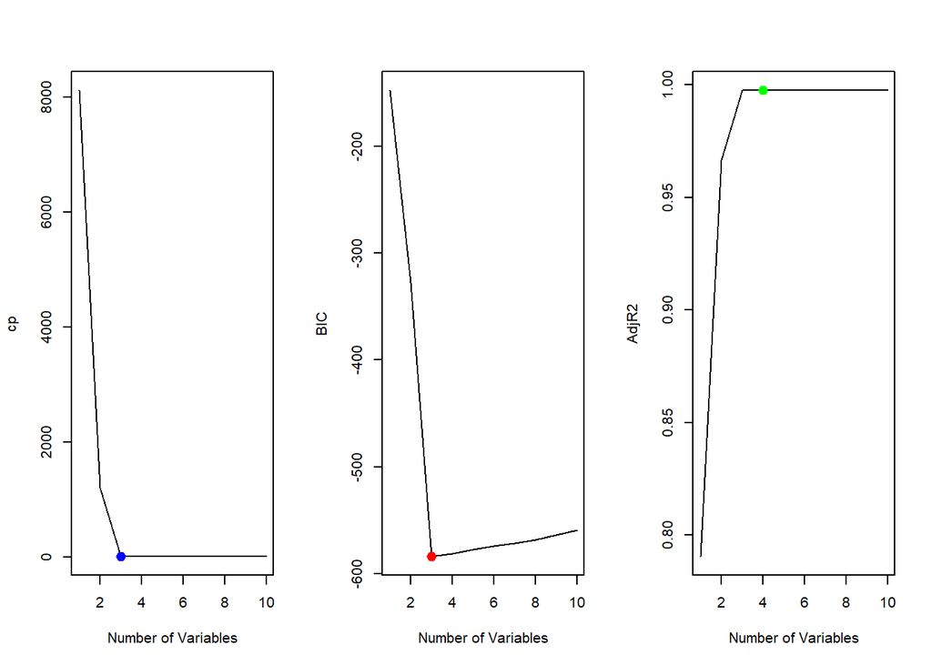

```r
plot(reg.summary$adjr2,xlab="Number of Variables",ylab="AdjR2",type="l")
points(which.max(regf.summary$adjr2),regf.summary$adjr2[which.max(regf.summary$adjr2)],col="green",cex=2,pch=20)
```

```r
which.max(regf.summary$adjr2)
```

```
## [1] 4
```

```r
coef(regfit.full, id =3)
```

```
## (Intercept)           x      I(x^2)      I(x^3)
##   19.939574  -10.193253    5.065504   -1.475092
```

```r
coef(regfit.full, id =4)
```

```
##  (Intercept)            x       I(x^2)       I(x^3)       I(x^4)
##  20.02018841 -10.13343968   4.84527802  -1.50331502   0.04786891
```

```r
coef(regfit.full, id =10)
```

```
##  (Intercept)            x       I(x^2)       I(x^3)       I(x^4)       I(x^5)
## 19.883290229 -9.972078891  6.391764990 -1.518789781 -2.116224444 -0.162347633
##       I(x^6)       I(x^7)       I(x^8)       I(x^9)      I(x^10)
##  0.995668582  0.066729152 -0.182008763 -0.006622356  0.011508441
```

#Stepwise Backward

```r
data.full <- data.frame(y = Y, x = X)
regfit.b <- regsubsets(y~x+I(x^2) + I(x^3) + I(x^4) + I(x^5) + I(x^6) + I(x^7) + I(x^8) + I(x^9) + I(x^10), data = data.full, nvmax = 10,really.big = T, method = 'backward')
regb.summary <- summary(regfit.b)
regb.summary
```

```
## Subset selection object
## Call: regsubsets.formula(y ~ x + I(x^2) + I(x^3) + I(x^4) + I(x^5) +
##     I(x^6) + I(x^7) + I(x^8) + I(x^9) + I(x^10), data = data.full,
##     nvmax = 10, really.big = T, method = "backward")
## 10 Variables  (and intercept)
##         Forced in Forced out
## x           FALSE      FALSE
## I(x^2)      FALSE      FALSE
## I(x^3)      FALSE      FALSE
## I(x^4)      FALSE      FALSE
## I(x^5)      FALSE      FALSE
## I(x^6)      FALSE      FALSE
## I(x^7)      FALSE      FALSE
## I(x^8)      FALSE      FALSE
## I(x^9)      FALSE      FALSE
## I(x^10)     FALSE      FALSE
## 1 subsets of each size up to 10
## Selection Algorithm: backward
##           x   I(x^2) I(x^3) I(x^4) I(x^5) I(x^6) I(x^7) I(x^8) I(x^9) I(x^10)
## 1  ( 1 )  "*" " "    " "    " "    " "    " "    " "    " "    " "    " "
## 2  ( 1 )  "*" "*"    " "    " "    " "    " "    " "    " "    " "    " "
## 3  ( 1 )  "*" "*"    "*"    " "    " "    " "    " "    " "    " "    " "
## 4  ( 1 )  "*" "*"    "*"    " "    " "    "*"    " "    " "    " "    " "
## 5  ( 1 )  "*" "*"    "*"    " "    " "    "*"    " "    "*"    " "    " "
## 6  ( 1 )  "*" "*"    "*"    "*"    " "    "*"    " "    "*"    " "    " "
## 7  ( 1 )  "*" "*"    "*"    "*"    " "    "*"    " "    "*"    " "    "*"
## 8  ( 1 )  "*" "*"    "*"    "*"    " "    "*"    "*"    "*"    " "    "*"
## 9  ( 1 )  "*" "*"    "*"    "*"    " "    "*"    "*"    "*"    "*"    "*"
## 10  ( 1 ) "*" "*"    "*"    "*"    "*"    "*"    "*"    "*"    "*"    "*"
```

```r
regb.summary$cp
```

```
##  [1] 8119.283890 1201.181577    3.821967    3.886543    5.499577    6.515339
##  [7]    6.523634    7.254331    9.041056   11.000000
```

```r
regb.summary$bic
```

```
##  [1] -148.0650 -328.1944 -583.9807 -581.4160 -577.2238 -573.6769 -571.2481
##  [8] -568.0550 -563.6891 -559.1300
```

```r
regb.summary$adjr2
```

```
##  [1] 0.7904099 0.9666164 0.9975044 0.9975291 0.9975131 0.9975128 0.9975399
##  [8] 0.9975478 0.9975264 0.9974998
```

#The statistical matrices are very similar to that for best subset selection

#cp decreases substancially from one variable model to two variable model. Again from two variable model to three variable model it decreases substancially and then again it keeps incresing

#BIC value is almost constant after three variable model and it is lowest for three variable model

```r
par(mfrow = c(1, 3))

plot(regb.summary$cp,xlab="Number of Variables",ylab="cp",type="l")
points(which.min(regb.summary$cp),regb.summary$cp[which.min(regb.summary$cp)],col="blue",cex=2,pch=20)
which.min(regb.summary$cp)
```

```
## [1] 3
```

```r
plot(reg.summary$bic,xlab="Number of Variables",ylab="BIC",type="l")
points(which.min(reg.summary$bic),regb.summary$bic[which.min(regb.summary$bic)],col="red",cex=2,pch=20)
which.min(regb.summary$bic)
```

```
## [1] 3
```

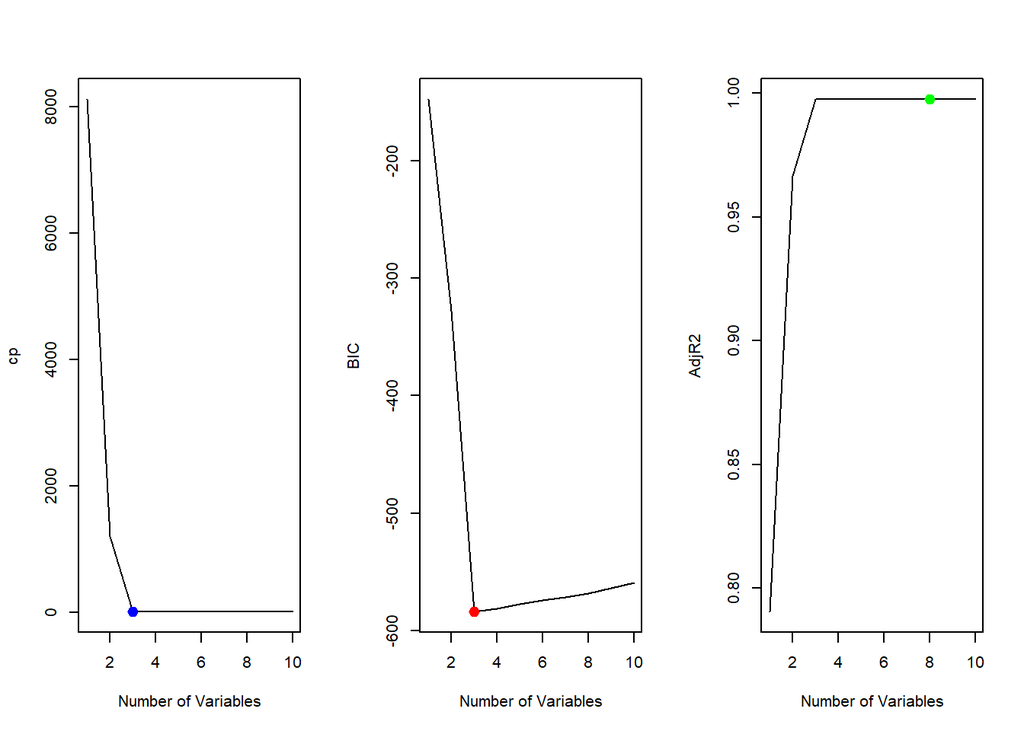

```r
plot(reg.summary$adjr2,xlab="Number of Variables",ylab="AdjR2",type="l")
points(which.max(regb.summary$adjr2),regb.summary$adjr2[which.max(regb.summary$adjr2)],col="green",cex=2,pch=20)
```

```r
which.max(regb.summary$adjr2)
```

```
## [1] 8
```

```r
coef(regfit.full, id =3)
```

```
## (Intercept)           x      I(x^2)      I(x^3)
##   19.939574  -10.193253    5.065504   -1.475092
```

```r
coef(regfit.full, id =4)
```

```
##  (Intercept)            x       I(x^2)       I(x^3)       I(x^4)
##  20.02018841 -10.13343968   4.84527802  -1.50331502   0.04786891
```

```r
coef(regfit.full, id =10)
```

```
##  (Intercept)            x       I(x^2)       I(x^3)       I(x^4)       I(x^5)
## 19.883290229 -9.972078891  6.391764990 -1.518789781 -2.116224444 -0.162347633
##       I(x^6)       I(x^7)       I(x^8)       I(x^9)      I(x^10)
##  0.995668582  0.066729152 -0.182008763 -0.006622356  0.011508441
```

#Results for backward selection are very similar to best subset and forward selection

#8e

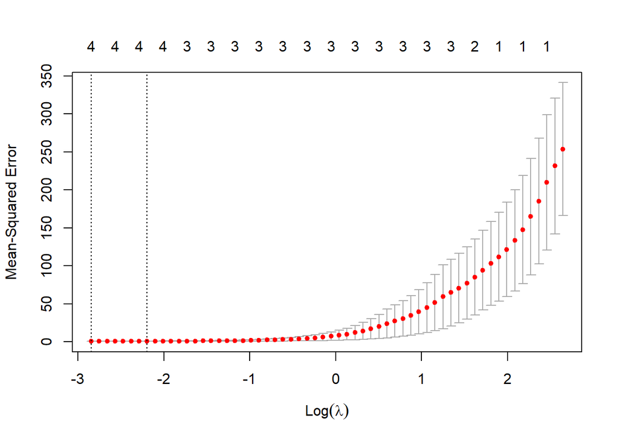

```r
set.seed(1)
xmat <- model.matrix(Y ~ X + I(x^2) + I(x^3) + I(x^4) + I(x^5) + I(x^6) + I(x^7) + I(x^8) + I(x^9) + I(x^10), data = data.full)[,-1]
set.seed(1)
cv.lasso <- cv.glmnet(xmat,Y,alpha=1)
plot(cv.lasso)
```

```r
bestlam<-cv.lasso$lambda.min
bestlam
```

```
## [1] 0.05805476
```

```r
fit.lasso<-glmnet(xmat,Y,alpha=1)
predict(fit.lasso,s=bestlam,type="coefficients")[1:11,]
```

```
##  (Intercept)            X       I(x^2)       I(x^3)       I(x^4)       I(x^5)
##  20.02855830 -10.16288229   4.90279542  -1.46864676   0.02450389   0.00000000
##       I(x^6)       I(x^7)       I(x^8)       I(x^9)      I(x^10)
##   0.00000000   0.00000000   0.00000000   0.00000000   0.00000000
```

#Higher values of lambda result in an increase in the MSE

#The lasso model creates a sparse model with four variables. The intercept and coefficients for X, X^2 and X^3 closely match the ones chosen in initially

#8f

```r
b0 <- 20
b7 <- 10
Y <- b0 + b7 * X^7 + e
data.full <- data.frame(y = Y, x = X)
regfit.full <- regsubsets(y ~ x + I(x^2) + I(x^3) + I(x^4) + I(x^5) + I(x^6) + I(x^7) + I(x^8) + I(x^9) + I(x^10), data = data.full, nvmax = 10)
reg.summary <- summary(regfit.full)
reg.summary$cp
```

```
##  [1]  3.6097823  0.3697446  1.8217119  2.6104969  3.5142503  4.8699206
##  [7]  5.2552047  7.0100195  9.0002919 11.0000000
```

```r
reg.summary$bic
```

```
##  [1] -1434.234 -1435.032 -1431.010 -1427.704 -1424.289 -1420.391 -1417.579
##  [8] -1413.248 -1408.654 -1404.049
```

```r
reg.summary$adjr2
```

```
##  [1] 0.9999995 0.9999995 0.9999995 0.9999995 0.9999995 0.9999995 0.9999995
##  [8] 0.9999995 0.9999995 0.9999995
```

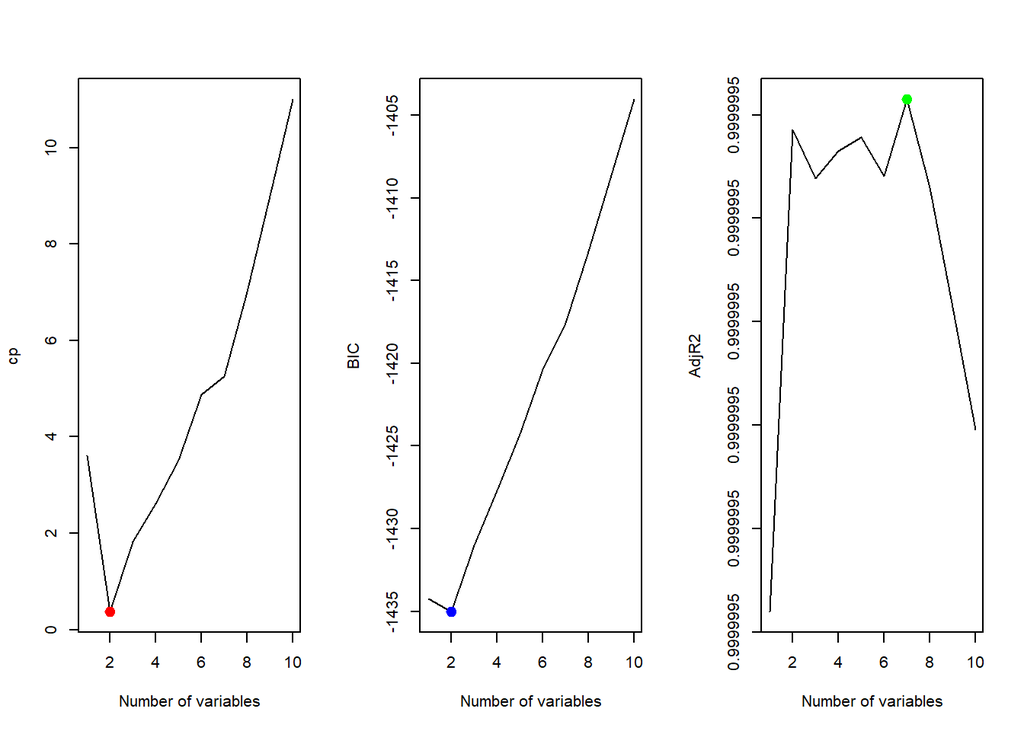

```r
par(mfrow = c(1, 3))
plot(reg.summary$cp, xlab = "Number of variables", ylab = "cp", type = "l")
points(which.min(reg.summary$cp), reg.summary$cp[which.min(reg.summary$cp)], col = "red", cex = 2, pch = 20)
plot(reg.summary$bic, xlab = "Number of variables", ylab = "BIC", type = "l")
points(which.min(reg.summary$bic), reg.summary$bic[which.min(reg.summary$bic)], col = "blue", cex = 2, pch = 20)
plot(reg.summary$adjr2, xlab = "Number of variables", ylab = "AdjR2", type = "l")
points(which.max(reg.summary$adjr2), reg.summary$adjr2[which.max(reg.summary$adjr2)], col = "green", cex = 2, pch = 20)
```

```r
coef(regfit.full,2)
```

```
## (Intercept)      I(x^3)      I(x^7)
##  19.9945045  -0.1097157  10.0036133
```

```r
coef(regfit.full,1)
```

```
## (Intercept)      I(x^7)
##    20.00817    10.00029
```

```r
coef(regfit.full,4)
```

```
##   (Intercept)        I(x^5)        I(x^7)        I(x^8)        I(x^9)
## 19.9739433646 -0.1470526386 10.0545974365  0.0007539692 -0.0050776231
```

#Adjusted R2 is 0.99999 for the one variable model and it remains constant

```r
xmat <- model.matrix(y ~ x + I(x^2) + I(x^3) + I(x^4) + I(x^5) + I(x^6) + I(x^7) + I(x^8) + I(x^9) + I(x^10), data = data.full)[, -1]
set.seed(1)
cv.lasso <- cv.glmnet(xmat, Y, alpha = 1)
bestlam <- cv.lasso$lambda.min
bestlam
```

```
## [1] 31.44378
```

```r
fit.lasso <- glmnet(xmat, Y, alpha = 1)
lasso.coef = predict(fit.lasso, s = bestlam, type = "coefficients")[1:11, ]
lasso.coef
```

```
## (Intercept)           x      I(x^2)      I(x^3)      I(x^4)      I(x^5)
##   22.972977    0.000000    0.000000    0.000000    0.000000    0.000000
##      I(x^6)      I(x^7)      I(x^8)      I(x^9)     I(x^10)
##    0.000000    9.708778    0.000000    0.000000    0.000000
```

#Lasso model using best value of lambda results in a sparse model with one variable

#It assigns a non-zero coefficient to the variable X^7 that explains the response Y

#Except for coefficient of X^7, it assigns zero to all the other coefficients